# RTP02 Exercises

Silvia Geiser

23/12/2020

# 1 Introduction

## 1.1 Create Time Series

What is the expected period (time period of repetition) and the time step for the following timeseries:

```r
dat = floor(runif(n= 1000, min = 1, max= 2000))
```

1. Sunshine duration per month in Basel from 1990 to 2000

```r
ts(data = dat, start=c(1990,1),end=c(2000,12), frequency = 12)
```

2. Number of newborn babies in the city of Zurich per year from 2000 to 2011

```r
ts(data=dat, start=2000,end=2011,frequency = 1)
```

c)Number of reservations in a restaurant for every night during 4 weeks

```r
ts(data=dat, start=1,end=4,frequency = 7)
```

4. Water runoff of a river. The data has been collected every day for 4 years

```r
ts(data=dat, start=1,end=4,frequency = 365)
```

## 1.2 Simulate Time Series

```r
zeitsim <- read.table('https://stat.ethz.ch/Teaching/Datasets/WBL/zeitsim.dat')
zeitsim.ts <- ts(zeitsim[,1:4], start = 1, frequency = 1)
```

Simulate timeseries according to the following models:

```r
set.seed(100)
Et <- ts(rnorm(101, 0, 1))
Et [1] <- 0
y1 <- 0

for (i in 2:length(Et)) {
  y1[i] <- Et[i]
  }

y1 <- y1[2:length(y1)]
ts.y1 <- ts(y1)
```

**a) Y1: Yt = Et − 0.5 · Et−1 , where Et ∼ N(0, 1) i.i.d. E0 = 0**

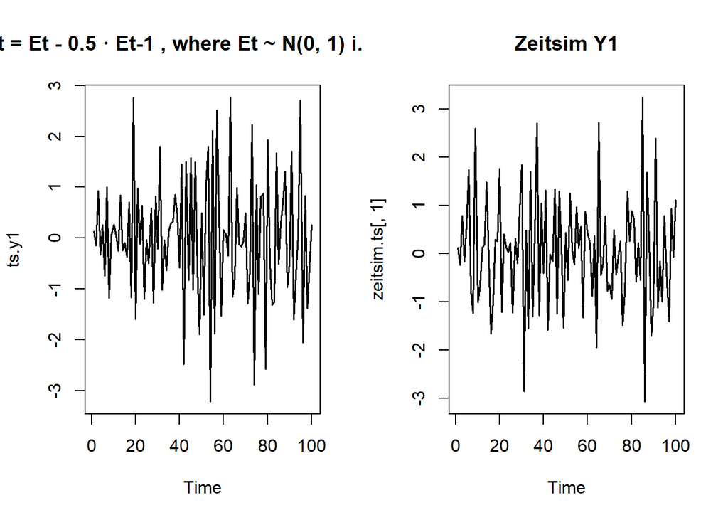

```r
set.seed(100)
Et <- ts(rnorm(101,0,1))
Et [1] <- 0
y1 <- 0
for (i in 2:length(Et)) {
  y1 [i] <- Et[i] - 0.5 * Et[i-1]
}

y1 <- y1[2:length(y1)]
ts.y1 <- ts(y1)

par(mfrow= c(1,2))
plot(ts.y1, lwd = 1.5, main = 'Y1: Yt = Et − 0.5 · Et−1 , where Et ∼ N(0, 1) i.i.d. E0 = 0')
plot(zeitsim.ts[,1], main = 'Zeitsim Y1', lwd = 1.5)
```

Answer: - stationary time series - MA(1) process

**b)Y2: Yt = Yt−1 + Et, where Et ∼ N(0, 1) i.i.d. Y0 = 0**

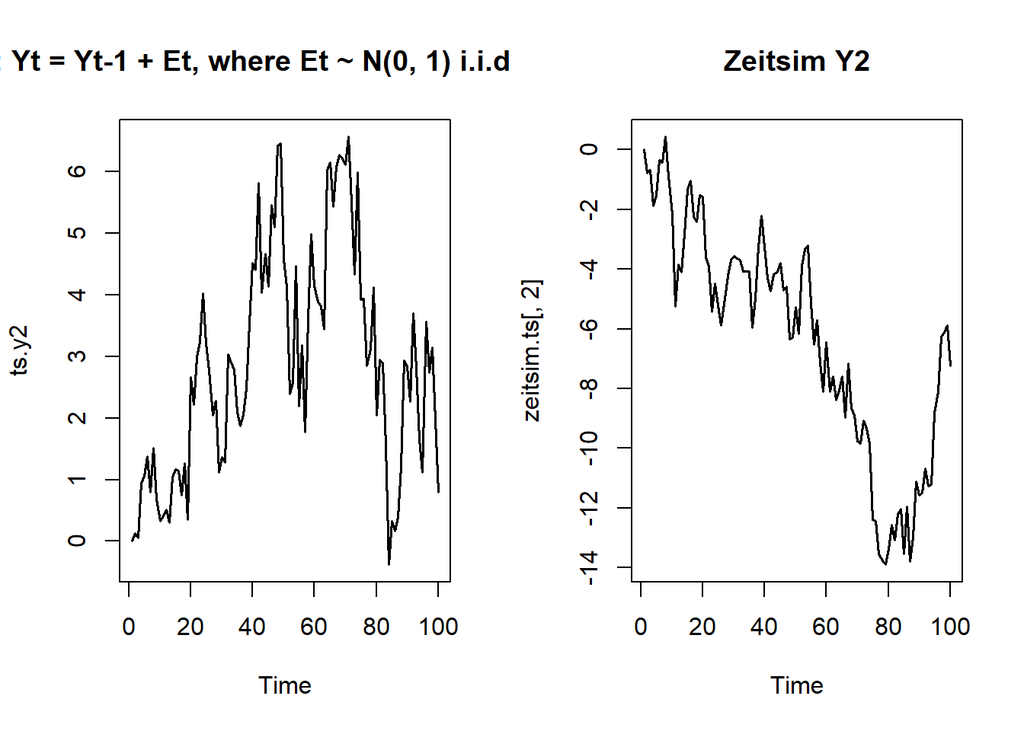

```r
set.seed(100)
Et <- ts(rnorm(100,0,1))
y2 <- 0
for (i in 2:length(Et)) {
  y2[i] <- y2[i-1] + Et[i]
}

ts.y2 <- ts(y2)

par(mfrow = c(1,2))
plot(ts.y2, main = 'Y2: Yt = Yt−1 + Et, where Et ∼ N(0, 1) i.i.d. Y0 = 0', lwd = 1.5)
plot(zeitsim.ts[,2], main = 'Zeitsim Y2', lwd = 1.5)
```

Answer: - non stationary time series - Yt-1 and Et are uncorrelated random variables

**c) Y3: Yt = 0.5 · Yt−1 + Et, where Et ∼ N(0, 1) i.i.d. Y0 = 0**

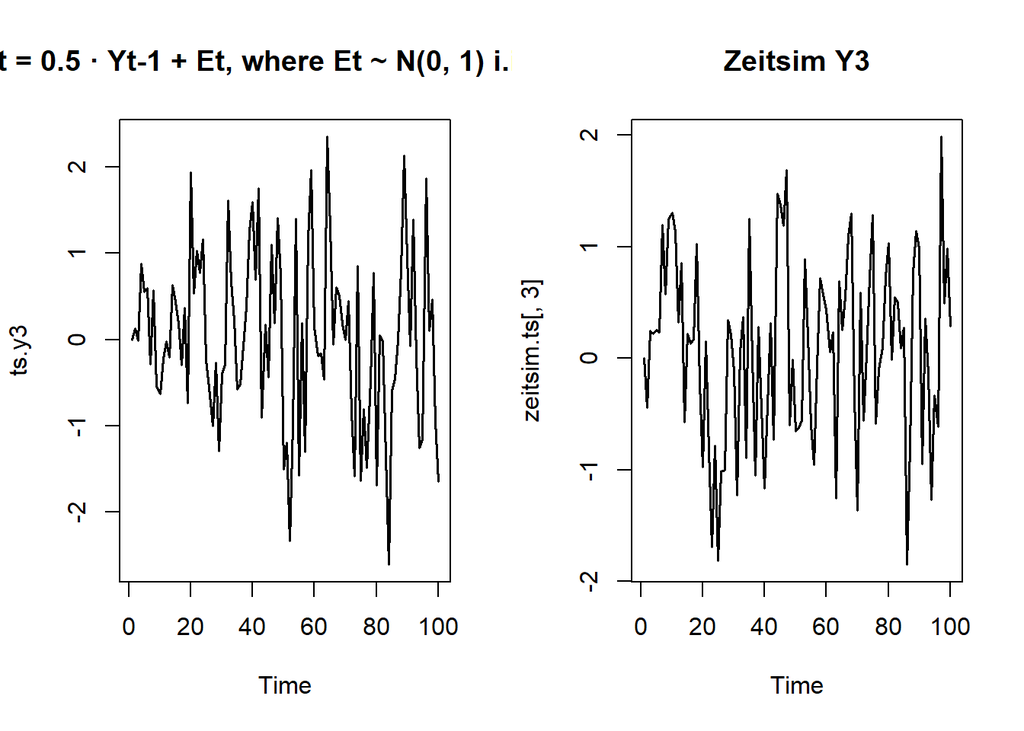

```r
set.seed(100)
Et <- ts(rnorm(100,0,1))
y3 <- 0
for (i in 2:length(Et)) {
  y3[i] <- 0.5 * y3[i - 1] + Et[i]
}

ts.y3 <- ts(y3)

par(mfrow = c(1,2))
plot(ts.y3, lwd = 1.5, main= 'Y3: Yt = 0.5 · Yt−1 + Et, where Et ∼ N(0, 1) i.i.d. Y0 = 0')
plot(zeitsim.ts[,3], main = 'Zeitsim Y3', lwd = 1.5)
```

Answer: - stationary time series - AR(1) process

**d) Y4: Yt = Yt−1 · Et, where Et ∼ U(0.95, 1.05) i.i.d. Y0 = 1**

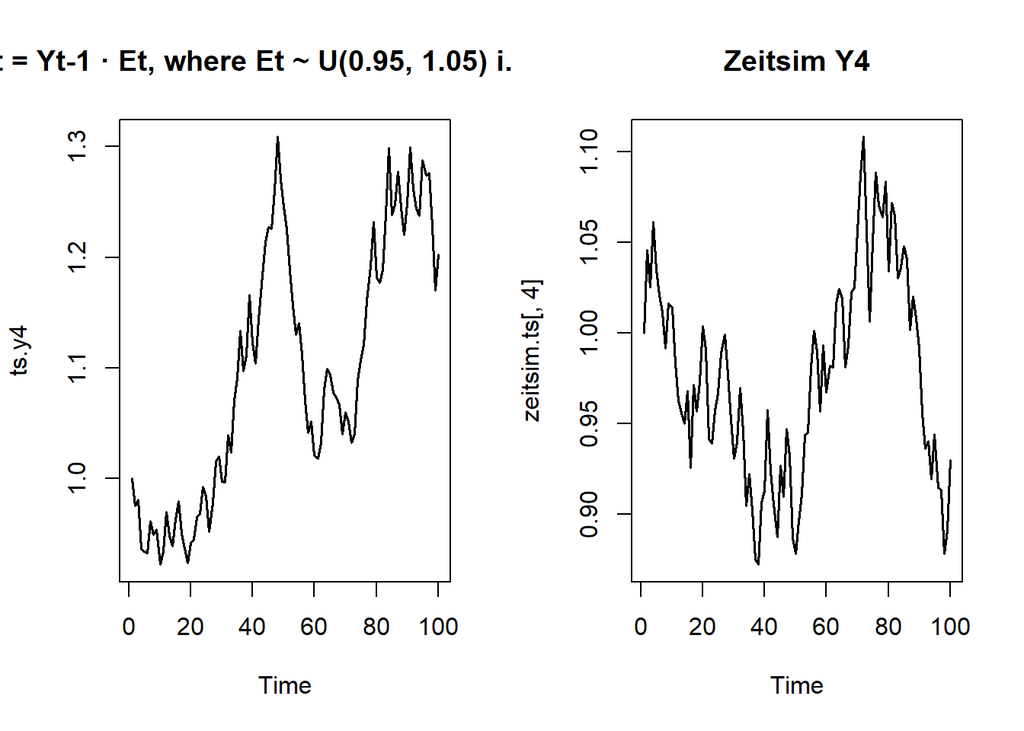

```r
set.seed(100)
Et <- ts(runif(100,0.95, 1.05))
y4 <- 1
for (i in 2:length(Et)) {
  y4[i] <- y4[i-1] * Et[i]
}

ts.y4 <- ts(y4)

par(mfrow= c(1,2))
ts.plot(ts.y4, main ='Y4: Yt = Yt−1 · Et, where Et ∼ U(0.95, 1.05) i.i.d. Y0 = 1', lwd = 1.5)
plot(zeitsim.ts[,4], main = 'Zeitsim Y4', lwd = 1.5)
```

Answer: - non stationary time series, as Var(Yt) is NOT constant

# 2 Transformation, Decomposition and Noise Treatment

## 2.1 Stationarity

A stationary time series is one whose properties do not depend on the time at which the series is observed. Thus, time series with trends, or with seasonality, are not stationary — the trend and seasonality will affect the value of the time series at different times. A white noise series is stationary — it does not matter when you observe it, it should look much the same at any point in time.

Some cases can be confusing — a time series with cyclic behaviour (but with no trend or seasonality) is stationary. This is because the cycles are not of a fixed length, so before we observe the series we cannot be sure where the peaks and troughs of the cycles will be.

In general, a stationary time series will have no predictable patterns in the long-term. Time plots will show the series to be roughly horizontal (although some cyclic behaviour is possible), with constant variance.

## 2.2 Skewness

The direction of the skew is dependent on whether the bulk of the material is above the mean line (negative skew) or below the mean line (positive skew).

[figure not shown]

## 2.3 Log Transformation

If the data show variation that increases or decreases with the level of the series, then a transformation can be useful. Logarithms can help to stabilise the variance of a time series. For example, if we denote the original observations as y1,…,yT and the transformed observations as w1,…,wT, then wt=log(yt). Logarithms are interpretable: changes in a log value are relative (or percentage) changes on the original scale. So if log base 10 is used, then an increase of 1 on the log scale corresponds to a multiplication of 10 on the original scale. Another useful feature of log transformations is that they constrain the forecasts to stay positive on the original scale.

Example (log is the logarithm to the base 10), i.e. log(1) = 0 log(10) = 1 log(100) =2 log(1000)=3 and so forth.

This means that the logarithm squezes all values between 1 and 10 to the range between 0 and 1, all values between 10 and 100 to the range between 1 and 2, and all values between 100 and 1000 to the range between 2 and 3. In conclusion, the higher the values get, the more the logarithm squeezes them together.

## 2.4 Differencing

One way to make a non-stationary time series stationary — compute the differences between consecutive observations. Computing the differences between consecutive observations, is known as differencing.

Differencing can help stabilise the mean of a time series by removing changes in the level of a time series, and therefore eliminating (or reducing) trend and seasonality.

Summary: + trend and seasonal effect can be removed + procedure is very quick and very simple to implement

- trend, season and remainder component are NOT known, and cannot be visualised
- resulting time series will be shorter than original data set
- differencing creates artificial new dependencies that are different from the original ones
- extrapolation of trend, season and remainder is not easily possible

## 2.5 Random Walk

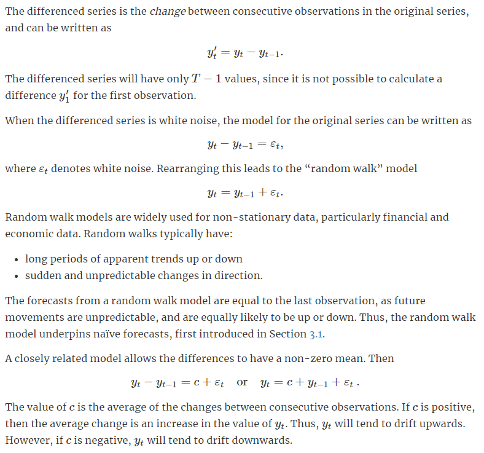

## 2.6 Second-order differencing

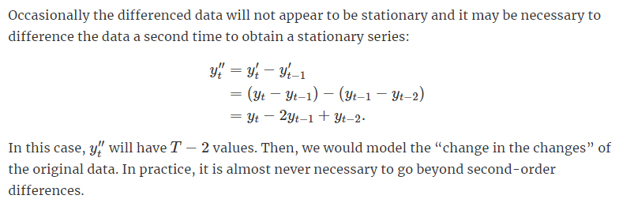

## 2.7 Seasonal differencing

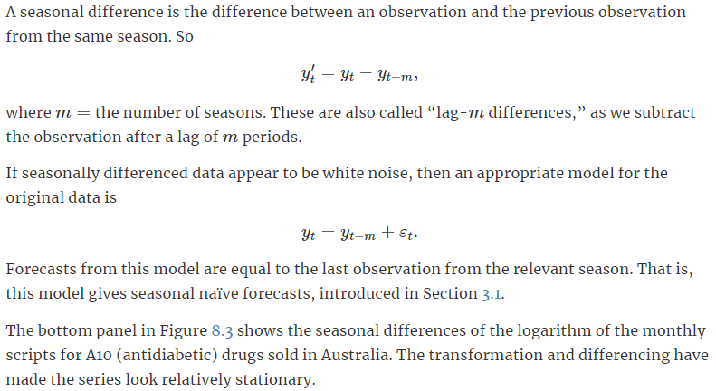

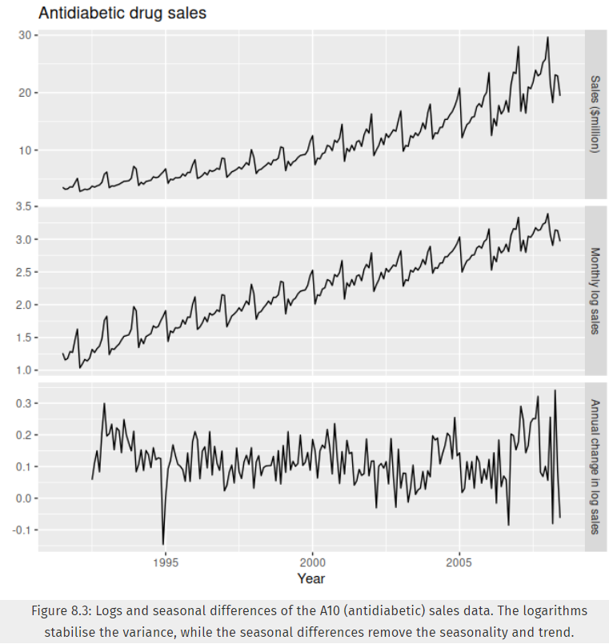

## 2.8 Backshift operator and Backshift notation

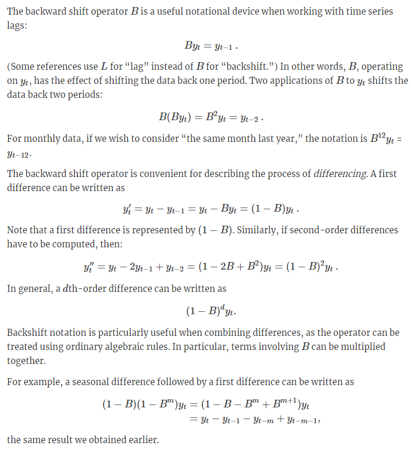

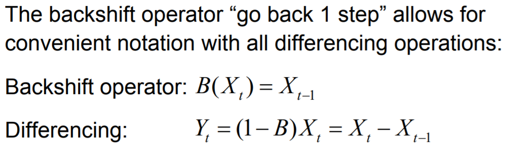

### 2.8.1 Remove linear Trend of a non-stationary time series by taking differences of first order at lag 1: diff(x, differences = 1)

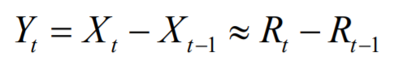

The new time series Yt is going to be stationary, but has new, strong and artificial dependencies

- Yt now are the observation to observation changes in the series, NOT longer the observations or remainder itself
- does not yield estimates for trend, season and remainder component

### 2.8.2 Differencing for log-transformed series: diff(log(x), differences = 1, lag = 1)

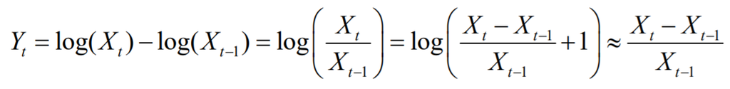

### 2.8.3 Remove polynomial Trend: diff(x, differences = 2 or more)

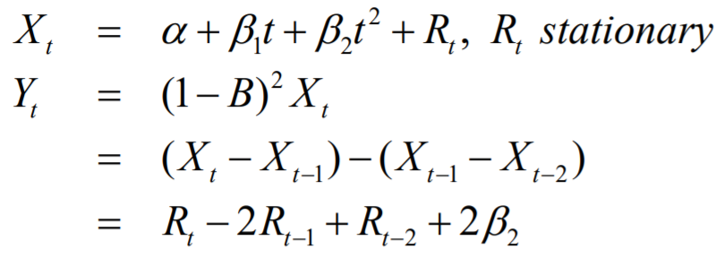

This will remove a polynomial trend. A quadratic trend can be removed by taking second-order differences (differences = 2).

Time series with seasonal effects can be made stationary through differencing by comparing to the previous periods’ value.

### 2.8.4 Remove Seasonality: diff(x, lag = p)

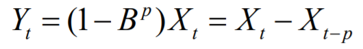

To remove Trend and Seasonality take first order differences at the lag = p of the period, which removes both trend and season effects: diff(x, differences = 1, lag = 12) example: p = 12

## 2.9 Identify characteristics of Time Series

Have a look at the following set of time series. For every series, shortly answer the following questions (motivate your answers): • Is the time series stationary? • Is there a trend? • Can one find some seasonal effect? If yes, what is the period? • Which transformation should be applied (if required)?

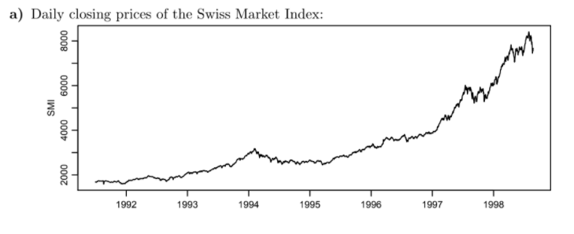

Answer: - non stationary - non linear trend, mostly increasing - no seasonal component - log transformation

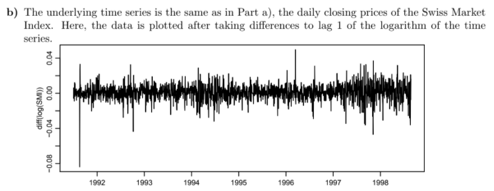

Answer: - seems stationary - trend from before was removed by diff(difference = 1) - constant variance achieved by taking the logarithm. However Log-Returns are NOT stationary, because of volatility clusters

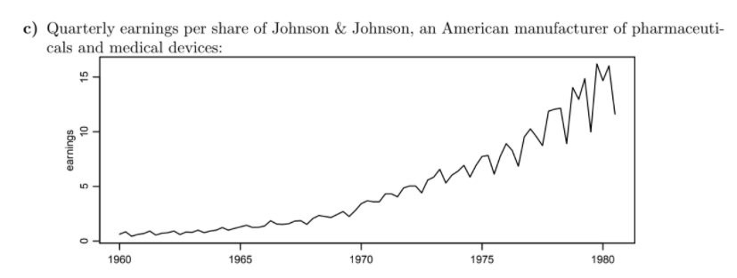

Answer: - non stationary - exponential increasing trend - seasonal component with period 1 year - increasing variance, log transformation benefitial to get additive components

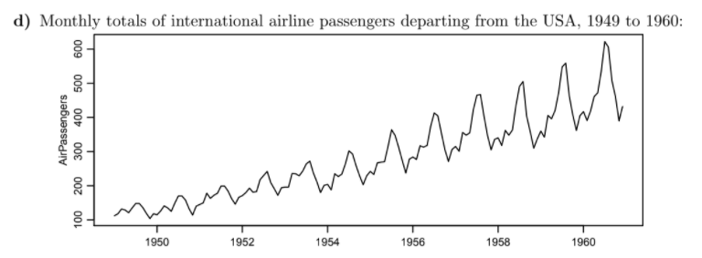

Answer: - non stationary - increasing trend - seasonal component with period 1 year and increasing variance - increasing variance, log transformation benefitial to get additibe components

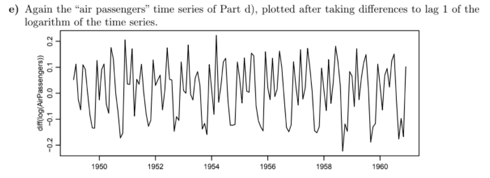

Answer: - non stationary - no visible trend - seasonal effect with period 1 year

Yeary numbers of sunspots:

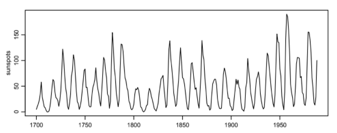

Answer: - likely to be stationary - no trend - no seasonal effect - periodicity with period of 11 years - variance maybe different over time - log transformation required due to right skewness

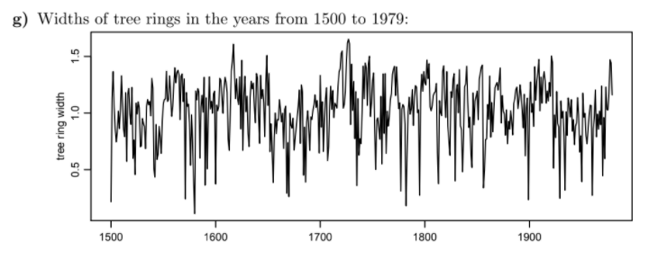

Answer: - probably stationary - no clear trend visible - no seasonal effect visible - no transformation required

## 2.10 Decomposition

The additive decomposition is the most appropriate if the magnitude of the seasonal fluctuations, or the variation around the trend-cycle, does not vary with the level of the time series.

When the variation in the seasonal pattern, or the variation around the trend-cycle, appears to be proportional to the level of the time series, then a multiplicative decomposition is more appropriate. Multiplicative decompositions are common with economic time series.

### 2.10.1 Basic Structures

The following two structures are considered for basic decomposition models: Additive: Xt = Trend + Seasonal + Random Multiplicative: Xt = Trend * Seasonal * Random

**How to Choose Between Additive and Multiplicative Decompositions** - The additive model is useful when the seasonal variation is relatively constant over time. - The multiplicative model is useful when the seasonal variation increases over time.

## 2.11 STL Decomposition

The Seasonal-Trend Decomposition Procedure by Loess • is an iterative, non-parametric smoothing algorithm • yields a simultaneous estimation of trend and seasonal effect -> robust! + very simple to apply + very illustrative and quick + seasonal effect can be constant or smoothly varying - model free, extrapolation and forecasting is difficult

-> Good method for „having a quick look at the data“

# 3 Quantitative Description and Correlation functions

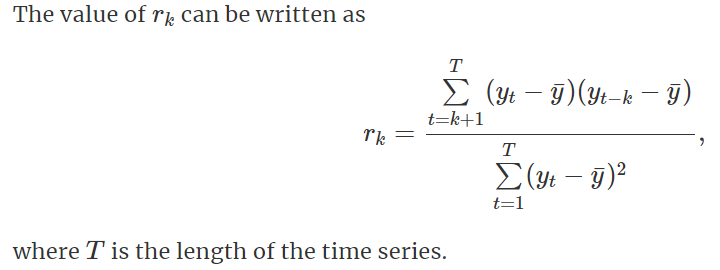

## 3.1 Autocorrelation ACF

The ACF plot is also useful for identifying non-stationary time series. For a stationary time series, the ACF will drop to zero relatively quickly, while the ACF of non-stationary data decreases slowly. Also, for non-stationary data, the value of r1 is often large and positive.

### 3.1.1 Trend in ACF plots

When data have a trend, the autocorrelations for small lags tend to be large and positive because observations nearby in time are also nearby in size. So the ACF of trended time series tend to have positive values that slowly decrease as the lags increase.

### 3.1.2 Season in ACF plots

When data are seasonal, the autocorrelations will be larger for the seasonal lags (at multiples of the seasonal frequency) than for other lags.

When data are both trended and seasonal, you see a combination of these effects.

## 3.2 Partial Autocorrelation PACF

## 3.3 White Noise

Time series that show no autocorrelation are called white noise. For white noise series, we expect each autocorrelation to be close to zero. Of course, they will not be exactly equal to zero as there is some random variation. For a white noise series, we expect 95% of the spikes in the ACF to lie within ±2/√T where T is the length of the time series. It is common to plot these bounds on a graph of the ACF. If one or more large spikes are outside these bounds, or if substantially more than 5% of spikes are outside these bounds, then the series is probably not white noise.

# 4 Modeling

Exponential smoothing and ARIMA models are the two most widely used approaches to time series forecasting, and provide complementary approaches to the problem. While exponential smoothing models are based on a description of the trend and seasonality in the data, ARIMA models aim to describe the autocorrelations in the data.

## 4.1 AR - Autoregressive Models

In an autoregression model, we forecast the variable of interest using a linear combination of past values of the variable. The term autoregression indicates that it is a regression of the variable against itself.

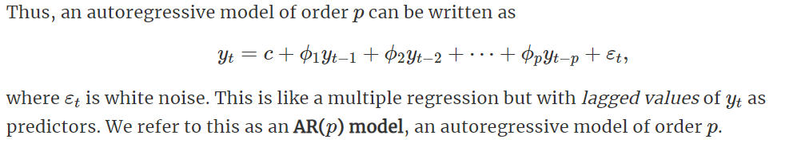

Changing the parameters ϕ1,…,ϕp results in different time series patterns.

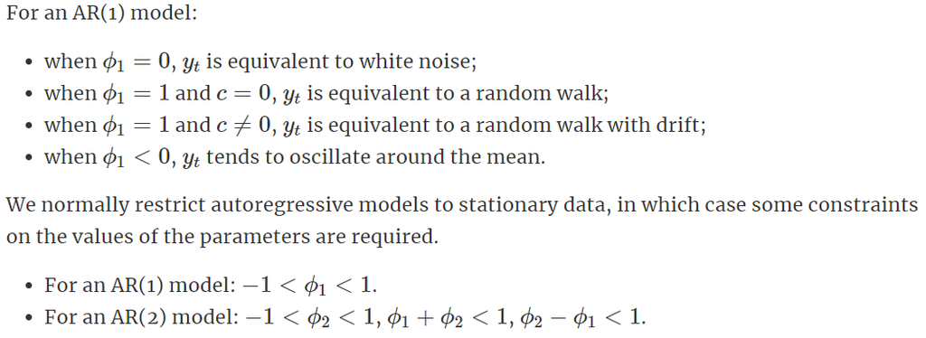

## 4.2 MA

## 4.3 ARMA

## 4.4 ARIMA

ARIMA models aim to describe the autocorrelations in the data.

## 4.5 SARIMA

## 4.6 (G)ARCH

# 5 Forecasting

# 6 Panel Data

# 7 Data sets and Exercises

## 7.1 Hstart Data Set

Using the data hstart.dat, we illustrate various methods for descriptive decomposition and elimination of trends. The data contains monthly data on the start of residential construction in the USA within the time frame of January 1966 to December 1974. The data have undergone some transformation unknown to us (perhaps an index over some baseline value has been calculated, or perhaps the data are to be read as x · 10^? construction permits).

```r
hstart <- read.table('https://stat.ethz.ch/Teaching/Datasets/WBL/hstart.dat')
hstart.ts <- ts(hstart[,1], start = c(1966,1), end = c(1974,12), frequency = 12)
```

Make a time series plot. Is this a stationary time series? If not, what kind of nonstationarity is evident?

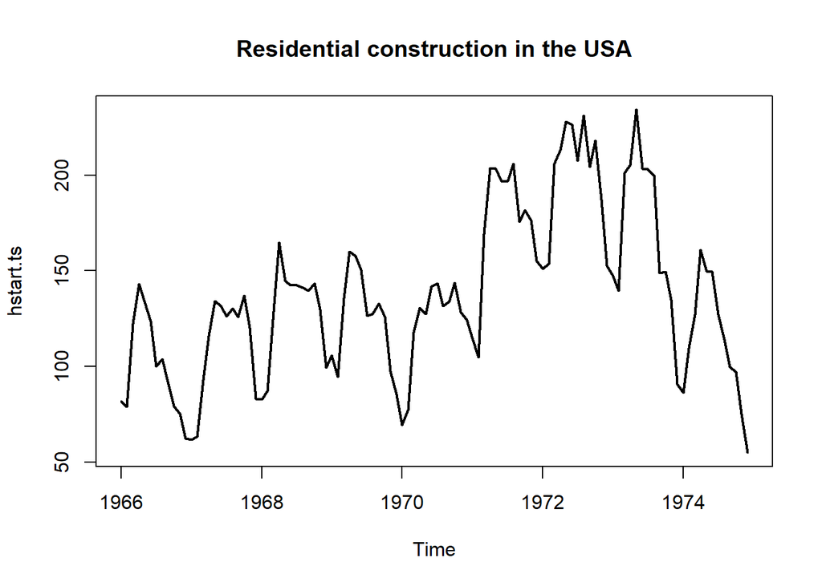

```r
plot(hstart.ts, lwd = 2, main = 'Residential construction in the USA')
```

- not stationary
- trend
- seasonal component
- decomposition possible into trend, seasonal effect and remainder:
2. Differences Try to remove the trend and seasonal effects by computing differences. After removing seasonal effects, choose some linear trend elimination method from the course notes and plot the outcome.

**R hint:** H.y <- diff(hstart, lag=12) # time series differences Yt = Xt − Xt−k, lag = k H.z <- diff(H.y, lag=…) par(mfrow=c(2,1)) plot(H.y) plot(H.z)

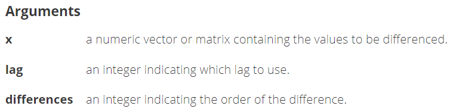

- Remove seasonal effects by differencing with lag = 12

```r
hstart.season.diff <- diff(hstart.ts, lag = 12)
```

[figure not shown]

```r
hstart.trend.diff <- diff(hstart.season.diff, differences = 1)
```

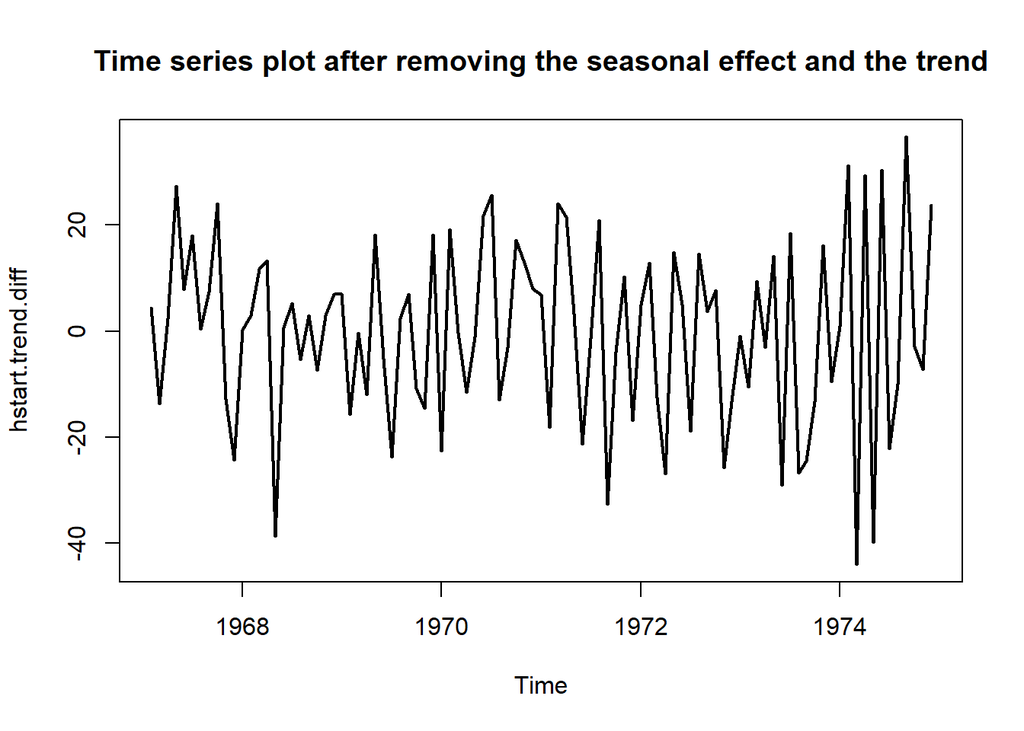

```r
plot(hstart.trend.diff, main = "Time series plot after removing the seasonal effect and the trend", lwd = 2)
```

Code in 2 steps as mentioned above in one code line:

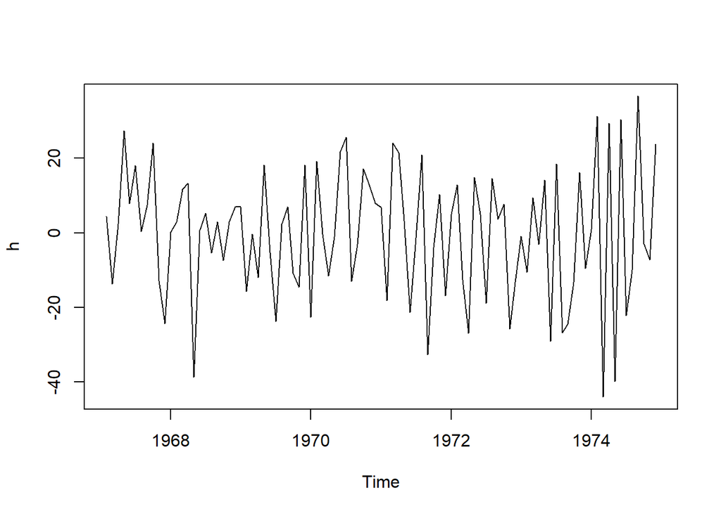

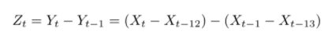

```r
h <- diff(diff(hstart.ts, lag = 12))
plot(h)
```